# Salary comparison using dplyr & ggplot2

Abiyu Giday

January 19, 2016

Ok, its time to log the second blog! The goal of this blog is to share some data wrangling techniques and analysis outcome presentation with R programming language. The process of structuring datasets to get it ready for analysis is referred as data “Tidying”…

## Summary

To help facilitate tidying and presenting the data, I will be using the Salaries dataset found in the *Companion to Applied Regression* (car) package. The question we will be seeking to answer from this analysis is: **For the same experience and education level is there parity between male and female professor’s salaries in US colleges?**

It is assumed some knowledge of R programming is necessary to understand the codes included in this document. However, the rest of the content should be self explanatory.

One of the key pillars of data analysis is getting a messy data and manipulating it to make it ready for further analysis. It is often said, even by more experienced data scientists, that **80%** of data analysis is spent on preparing and cleaning data. Good news is R has several packages that can do the cleaning. The challenge with R is that there are too many different ways of performing the same tasks. And hat can lead to confusion. Depending on your level of experience and inclination you have choices that can help you wrangle and clean the data. [Hadly Wickham’s work](https://twitter.com/hadleywickham/likes), especially on [dplyr](https://cran.r-project.org/web/packages/dplyr/index.html), is one of the best R packages out there. With just few lines of codes, logically constructed, one can *wrangle* or manipulate data, large and small, and can whip a messy data in to shape very fast!

The **Salaries** dataset from the [Companion to Applied Regression package](https://cran.r-project.org/web/packages/car/index.html) (car) is a 2008-09 nine-month academic salary for Assistant Professors, Associate Professors and Professors in a college through out the US. The data were collected as part of the on-going effort of the college’s administration to monitor salary differences between male and female faculty members.

## Explore The Data

First order of business is to load the data into R memory:

```r
library(dplyr)
library(car)
library(knitr)
library(DT)
datatable(Salaries)
```

|  | rank | discipline | yrs.since.phd | yrs.service | sex | salary |
| --- | --- | --- | --- | --- | --- | --- |
| 1 | Prof | B | 19 | 18 | Male | 139750 |
| 2 | Prof | B | 20 | 16 | Male | 173200 |
| 3 | AsstProf | B | 4 | 3 | Male | 79750 |
| 4 | Prof | B | 45 | 39 | Male | 115000 |
| 5 | Prof | B | 40 | 41 | Male | 141500 |
| 6 | AssocProf | B | 6 | 6 | Male | 97000 |
| 7 | Prof | B | 30 | 23 | Male | 175000 |
| 8 | Prof | B | 45 | 45 | Male | 147765 |
| 9 | Prof | B | 21 | 20 | Male | 119250 |
| 10 | Prof | B | 18 | 18 | Female | 129000 |

[output cut: 387 more lines]

```r
#kable(head(arrange(Salaries, desc(as.numeric(salary))), 10))
```

```r
str(Salaries)
```

```
## 'data.frame':    397 obs. of  6 variables:
##  $ rank         : Factor w/ 3 levels "AsstProf","AssocProf",..: 3 3 1 3 3 2 3 3 3 3 ...
##  $ discipline   : Factor w/ 2 levels "A","B": 2 2 2 2 2 2 2 2 2 2 ...
##  $ yrs.since.phd: int  19 20 4 45 40 6 30 45 21 18 ...
##  $ yrs.service  : int  18 16 3 39 41 6 23 45 20 18 ...
##  $ sex          : Factor w/ 2 levels "Female","Male": 2 2 2 2 2 2 2 2 2 1 ...
##  $ salary       : int  139750 173200 79750 115000 141500 97000 175000 147765 119250 129000 ...
```

```r
#Always check if there is missing data
sum(is.na(Salaries))
```

```
## [1] 0
```

```r
#summary of the salary quartile distribution
summary(Salaries$salary)
```

```
##    Min. 1st Qu.  Median    Mean 3rd Qu.    Max.
##   57800   91000  107300  113700  134200  231500
```

Next we want to see the men vs women breakdown, and count numbers of of Professors, Associate Professors and Assistance Professors.

```r
# How many Male and how many Female
table(Salaries$sex)
```

```
##
## Female   Male
##     39    358
```

```r
#How many prof, assoc, assit
table(Salaries$rank)
```

```
##
##  AsstProf AssocProf      Prof
##        67        64       266
```

A quick plot (qplot), from *ggplot2* package, of the data will reveal the distribution of salary for both men and women separately. Box plot graph shows a five number summary. The horizontal line in the middle of each box shows the **median**, and the box top/bottom lines show the first and third quartile.

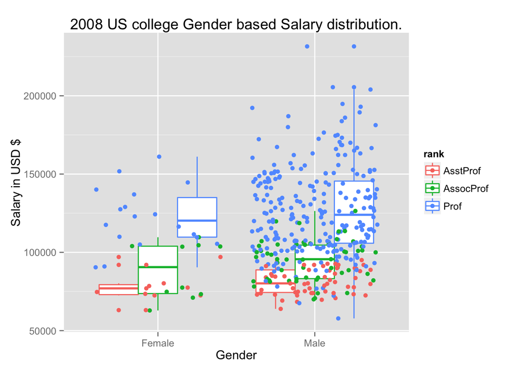

```r
library(ggplot2)
#box plot shows
qplot(sex, salary, data = Salaries, geom=c("boxplot", "jitter"), colour = rank, main="2008 US college Gender based Salary distribution.", xlab = "Gender", ylab = "Salary in USD $" )
```

From the Graph, we can see that there are more men professors than there are women, and more men professor earn higher salary than associate or assistant professor. In order to make an apple to apple comparison and answer our stated question we have to **manipulate** the data in a way that we can compare the averages of men and women Assistant Professors, Associate Professors and Professors with the respective rank. The next step uses dplyr to get the data ready.

## Tidy data with dplyr

```r
library(dplyr)                  #Load a dplyr
#Average overall salary of men
Salaries %>%
        filter( sex == "Male" ) %>%
          select(salary) %>%
            summarise_each(funs(mean))
```

```
##     salary
## 1 115090.4
```

```r
#Average overall salary for women
Salaries %>%
        filter( sex == "Female") %>%
           select(salary) %>%
              summarise_each(funs(mean))
```

```
##     salary
## 1 101002.4
```

```r
tt <- Salaries %>%
    group_by(rank, salary, sex) %>%
           select(sex, rank, salary, yrs.service)
head(tt)
```

```
## Source: local data frame [6 x 4]
## Groups: rank, salary, sex [6]
##
##      sex      rank salary yrs.service
##   (fctr)    (fctr)  (int)       (int)
## 1   Male      Prof 139750          18
## 2   Male      Prof 173200          16
## 3   Male  AsstProf  79750           3
## 4   Male      Prof 115000          39
## 5   Male      Prof 141500          41
## 6   Male AssocProf  97000           6
```

## Graphs

First, we will be using the quick plot function to generate a faceted plot for each gender and their respective counts.

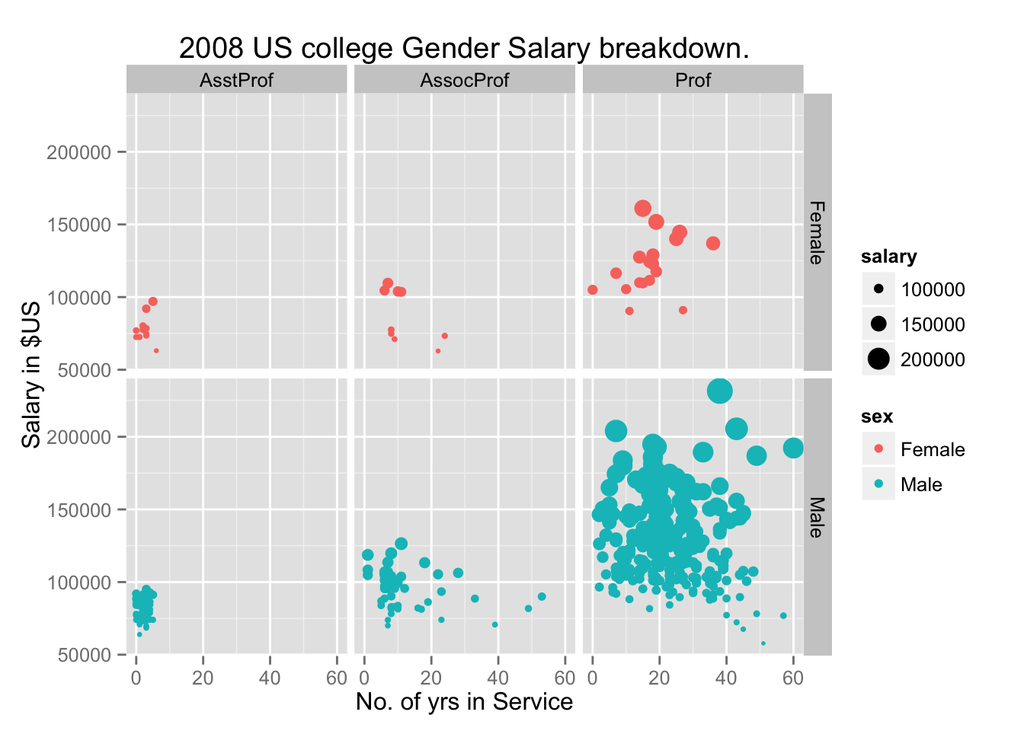

```r
qplot(yrs.service, salary, data = tt, colour = sex, size = salary, facets = sex ~ rank ,main="2008 US college Gender Salary breakdown.", xlab = "No. of yrs in Service", ylab = "Salary in $US" )
```

The graph shows that there are more men in all ranked categories. The size of the bubble indicates the magnitude of the salary. This shows that there are more men earning higher salary than women professors ,for example.

Because there are more male professors in the dataset than there are women, we have to find the average salary per rank and gender to make the comparison equivalent. The following code uses *dplyr* and wrangles the original data to render a dataframe named ‘pp’. This new data frame will be used to plot the final comparison charts.

```r
pp <- Salaries %>%
        group_by(sex, rank) %>%
           select(sex, rank, salary, yrs.service) %>%
                                summarise_each(funs(mean))
pp
```

```
## Source: local data frame [6 x 4]
## Groups: sex [?]
##
##      sex      rank    salary yrs.service
##   (fctr)    (fctr)     (dbl)       (dbl)
## 1 Female  AsstProf  78049.91    2.545455
## 2 Female AssocProf  88512.80   11.500000
## 3 Female      Prof 121967.61   17.111111
## 4   Male  AsstProf  81311.46    2.339286
## 5   Male AssocProf  94869.70   12.037037
## 6   Male      Prof 127120.82   23.229839
```

The following graph uses the new data frame (pp) and to plot the graph that will answer our question.

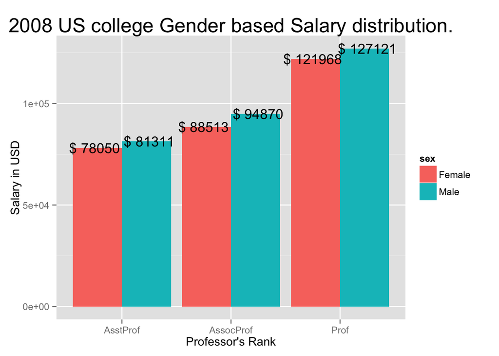

```r
ggplot(pp, aes(x = rank, y = salary, fill=sex)) +
        geom_bar(stat="identity", position=position_dodge()) +
        ggtitle("2008 US college Gender based Salary distribution.") +
        xlab("Professor's Rank") +
        ylab("Salary in USD") +
        theme(plot.title = element_text(size = 20), axis.title.x = element_text(size = 12), axis.title.y = element_text(size = 12)) +
        geom_text(aes(label = paste("$",round(salary)), y = salary), position = position_dodge(width=1), size = 5)
```

The plot clearly shows the salary comparison of men vs women in their respective teaching ranks.

## Conclusion

The answer to our question as to who earns more salary in colleges between 2008-09 is answered from the graph. **Men, on the average, earn more than women on every category.** Going one step further, utilizing the yrs.service feature in the dataset, what if we want to find out what the pay comparison was for women after serving five, ten or fifteen years. Did it get better worse?

The following ggplot plot will answer that question.

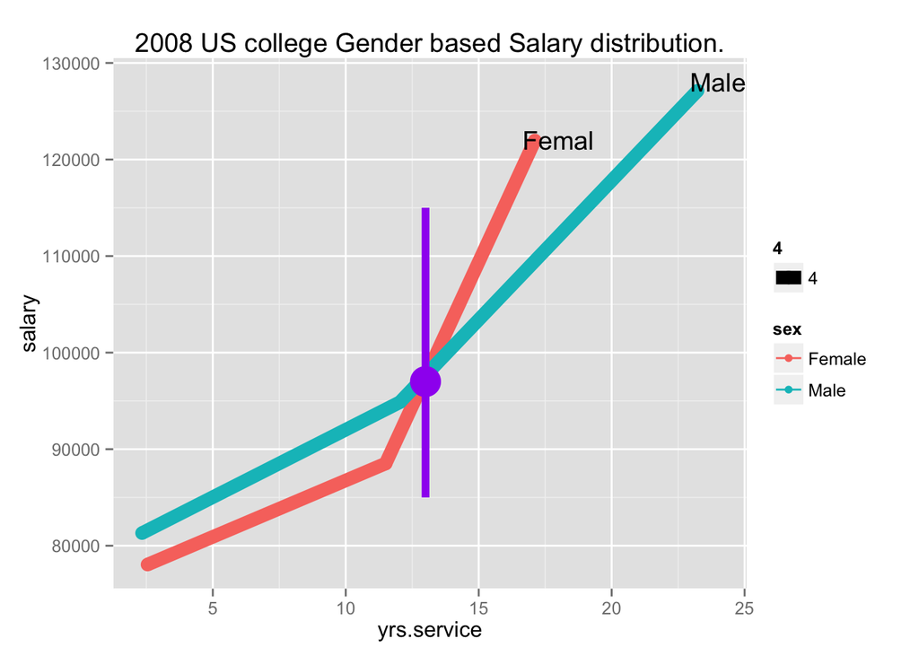

```r
ggplot(data=pp, aes(x=yrs.service, y=salary, group=sex, colour=sex, size=4)) +
        geom_line() +
        geom_point() +
        ggtitle("2008 US college Gender based Salary distribution.") +
        #facet_grid(sex ~ .) +
        annotate("text", x = 18, y = 122000, label = "Femal") +
        annotate("text", x = 24, y = 128000, label = "Male") +
        annotate("pointrange", x = 13, y = 97000, ymin = 85000, ymax = 115000, colour = "purple", size = 2)
```

[output not shown]